# Cal Men's Basketball PAC-12 Tournament Writeup

Instructor: Lon Rork

Men's PAC-12 Tournament Makeup Assignment

James Rigassio - jrigassio@berkeley.edu

P.E. Basketball Level - 2 MW 11a-12p

**The Cal Bears:** our beloved, young, garbage-can fire of a D1 basketball team

Let's talk about how they did at the recent PAC-12 Tournament in Las Vegas, NV. I had the great fortune of attending as a member of the University of California Marching Band (in which I play the trumpet). We were drawn up against the farm, and although Stanfurd was actually one of our few conference road wins this year, they emphatically sent us home from Vegas. Several things went wrong in our first-round exit to our Bay Area rivals.

I assume this is the first P.E. basketball make-up assignment to be turned in as an interactive Python Notebook hosted on [my website](https://rigass.io), but I hope you'll allow me a little creative libery. I use data retrieved from [here](https://www.sports-reference.com/cbb/boxscores/2018-03-07-17-stanford.html) (sports-reference.com) to augment my analysis. All the coding is done in Python3 using the following libraries: datascience, matplotlib, and numpy.

```python
#import libraries
import datascience as ds
import matplotlib.pyplot as plt
import numpy as np
%matplotlib inline
```

Let's start off with the box scores:

```python
bearsTable=ds.Table.read_table("bearsBoxScore.csv")
print("Cal")
bearsTable.show()
furdTable=ds.Table.read_table("furdBoxScore.csv")
print("Stanfurd")
furdTable.show()
```

```
Cal
```

| Starters | MP | FG | FGA | FG% | 2P | 2PA | 2P% | 3P | 3PA | 3P% | FT | FTA | FT% | ORB | DRB | TRB | AST | STL | BLK | TOV | PF | PTS |
| --- | --- | --- | --- | --- | --- | --- | --- | --- | --- | --- | --- | --- | --- | --- | --- | --- | --- | --- | --- | --- | --- | --- |
| Darius McNeill | 36 | 7 | 17 | 0.412 | 2 | 7 | 0.286 | 5 | 10 | 0.5 | 0 | 0 | nan | 1 | 1 | 2 | 0 | 3 | 0 | 1 | 1 | 19 |
| Justice Sueing | 29 | 3 | 10 | 0.3 | 2 | 5 | 0.4 | 1 | 5 | 0.2 | 1 | 4 | 0.25 | 1 | 4 | 5 | 2 | 1 | 0 | 2 | 0 | 8 |
| Don Coleman | 21 | 0 | 8 | 0 | 0 | 5 | 0 | 0 | 3 | 0 | 1 | 2 | 0.5 | 5 | 3 | 8 | 0 | 0 | 0 | 1 | 0 | 1 |
| Juhwan Harris-Dyson | 20 | 5 | 9 | 0.556 | 5 | 8 | 0.625 | 0 | 1 | 0 | 1 | 2 | 0.5 | 2 | 2 | 4 | 0 | 0 | 0 | 2 | 5 | 11 |
| Marcus Lee | 17 | 1 | 8 | 0.125 | 1 | 8 | 0.125 | 0 | 0 | nan | 0 | 0 | nan | 4 | 2 | 6 | 0 | 0 | 0 | 2 | 5 | 2 |
| Kingsley Okoroh | 33 | 2 | 5 | 0.4 | 2 | 5 | 0.4 | 0 | 0 | nan | 2 | 2 | 1 | 1 | 5 | 6 | 0 | 0 | 5 | 1 | 4 | 6 |
| Roman Davis | 18 | 0 | 6 | 0 | 0 | 5 | 0 | 0 | 1 | 0 | 2 | 6 | 0.333 | 1 | 2 | 3 | 1 | 1 | 0 | 0 | 3 | 2 |
| Nick Hamilton1 | 15 | 0 | 2 | 0 | 0 | 1 | 0 | 0 | 1 | 0 | 2 | 2 | 1 | 1 | 0 | 1 | 0 | 1 | 0 | 2 | 1 | 2 |
| Jacob Orender | 3 | 0 | 1 | 0 | 0 | 1 | 0 | 0 | 0 | nan | 2 | 2 | 1 | 0 | 1 | 1 | 0 | 0 | 0 | 0 | 0 | 2 |
| Derek King | 2 | 2 | 3 | 0.667 | 1 | 1 | 1 | 1 | 2 | 0.5 | 0 | 0 | nan | 0 | 1 | 1 | 0 | 0 | 0 | 0 | 0 | 5 |
| Austin McCullough | 2 | 0 | 0 | nan | 0 | 0 | nan | 0 | 0 | nan | 0 | 0 | nan | 0 | 0 | 0 | 0 | 0 | 0 | 0 | 0 | 0 |
| Grant Anticevich | 2 | 0 | 0 | nan | 0 | 0 | nan | 0 | 0 | nan | 0 | 0 | nan | 2 | 1 | 3 | 0 | 0 | 0 | 0 | 0 | 0 |
| Cole Welle | 2 | 0 | 2 | 0 | 0 | 0 | nan | 0 | 2 | 0 | 0 | 0 | nan | 0 | 1 | 1 | 0 | 0 | 0 | 0 | 0 | 0 |
| **School Total** | 200 | 20 | 71 | 0.282 | 13 | 46 | 0.283 | 7 | 25 | 0.28 | 11 | 20 | 0.55 | 18 | 23 | 41 | 3 | 6 | 5 | 11 | 19 | 58 |

```
Stanfurd
```

| Starters | MP | FG | FGA | FG% | 2P | 2PA | 2P% | 3P | 3PA | 3P% | FT | FTA | FT% | ORB | DRB | TRB | AST | STL | BLK | TOV | PF | PTS |
| --- | --- | --- | --- | --- | --- | --- | --- | --- | --- | --- | --- | --- | --- | --- | --- | --- | --- | --- | --- | --- | --- | --- |
| Daejon Davis | 33 | 4 | 6 | 0.667 | 3 | 4 | 0.75 | 1 | 2 | 0.5 | 3 | 4 | 0.75 | 0 | 3 | 3 | 3 | 2 | 0 | 4 | 0 | 12 |
| Dorian Pickens | 31 | 6 | 14 | 0.429 | 2 | 5 | 0.4 | 4 | 9 | 0.444 | 0 | 1 | 0 | 0 | 4 | 4 | 2 | 1 | 1 | 0 | 0 | 16 |
| Reid Travis | 27 | 7 | 11 | 0.636 | 7 | 11 | 0.636 | 0 | 0 | nan | 5 | 8 | 0.625 | 6 | 7 | 13 | 3 | 0 | 0 | 1 | 4 | 19 |
| Kezie Okpala | 21 | 1 | 4 | 0.25 | 1 | 3 | 0.333 | 0 | 1 | 0 | 2 | 2 | 1 | 2 | 4 | 6 | 3 | 3 | 1 | 1 | 3 | 4 |
| Michael Humphrey | 17 | 0 | 6 | 0 | 0 | 5 | 0 | 0 | 1 | 0 | 0 | 0 | nan | 2 | 2 | 4 | 1 | 0 | 1 | 2 | 3 | 0 |
| Oscar Da Silva | 25 | 3 | 7 | 0.429 | 0 | 3 | 0 | 3 | 4 | 0.75 | 0 | 3 | 0 | 2 | 6 | 8 | 2 | 0 | 0 | 2 | 1 | 9 |
| Josh Sharma | 15 | 5 | 6 | 0.833 | 5 | 5 | 1 | 0 | 1 | 0 | 2 | 2 | 1 | 0 | 2 | 2 | 0 | 0 | 0 | 0 | 4 | 12 |
| Robert Cartwright | 10 | 0 | 2 | 0 | 0 | 2 | 0 | 0 | 0 | nan | 0 | 0 | nan | 2 | 1 | 3 | 0 | 0 | 0 | 1 | 0 | 0 |
| Kodye Pugh | 6 | 1 | 1 | 1 | 1 | 1 | 1 | 0 | 0 | nan | 0 | 0 | nan | 1 | 0 | 1 | 0 | 0 | 0 | 1 | 0 | 2 |
| Isaac White | 6 | 0 | 2 | 0 | 0 | 0 | nan | 0 | 2 | 0 | 2 | 2 | 1 | 0 | 0 | 0 | 0 | 0 | 0 | 1 | 0 | 2 |
| Trevor Stanback | 5 | 0 | 0 | nan | 0 | 0 | nan | 0 | 0 | nan | 0 | 0 | nan | 0 | 0 | 0 | 0 | 0 | 0 | 0 | 1 | 0 |
| Rodney Herenton | 2 | 0 | 1 | 0 | 0 | 1 | 0 | 0 | 0 | nan | 0 | 0 | nan | 0 | 0 | 0 | 0 | 0 | 0 | 0 | 0 | 0 |
| Blake Pagon | 2 | 0 | 1 | 0 | 0 | 0 | nan | 0 | 1 | 0 | 0 | 0 | nan | 0 | 2 | 2 | 0 | 0 | 0 | 0 | 0 | 0 |
| **School Total** | 200 | 27 | 61 | 0.443 | 19 | 40 | 0.475 | 8 | 21 | 0.381 | 14 | 22 | 0.636 | 15 | 31 | 46 | 14 | 6 | 3 | 13 | 16 | 76 |

The thing that jumped out to me the most from being at the game was Darius McNeill's performance. In the first half, he gave Cal 19 points, and as you'd infer from the box stats, he scored 0 in the second. It wasn't that his shot was off in the second half, he just stopped shooting for some reason. I saw McNeill take close to no shots in the second half, and I think the team could have used his 50% efficiency from behind the arc to help overcome the huge deficit. While watching, I kept wondering why this happened. It didn't seem like he was being guarded more closely, and I wonder if it was something that Coach Wyking Jones had him do. Let's have a pie chart:

```
Cal's First Half Points
```

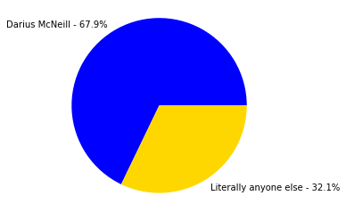

```python
print("Cal's First Half Points")
labels = ['Darius McNeill - {}%'.format(round(19/28, 3) * 100), 'Literally anyone else - {}%'.format(round(9/28, 3) * 100)]
points = [19, 9]
colors = ['blue', 'gold']

plt.pie(points, labels=labels, colors=colors)
plt.axis('equal')
plt.show()
```

Now, I understand that if you're down 11 in the first half, asking your starting point guard to pass the ball more could make sense. He was the only player well into double figures, and experimenting with tactics to try and improve the outcome of the game makes sense. However, if any player is 5 for 10 from the three-point line in the first half, a coach has to make sure they keep shooting in the second. While the team played better overall in the second half, McNeill should have been utilized more. It didn't seem to me that the opposing players were defending him to the point where he couldn't shoot, and I can't imagine why a hot streak in the first half that carried the team was snubbed out in the second.

The second thing that appears to have gone horribly wrong, from the stats, are the assist totals for each team. The bears had 3, the farm had 14. From watching warriors games, I know that having more assists in a game indicates two things:

1. The team scored more, as each assist corresponds to a shot made
2. The team has allowed for more ball movement, which tends to be a good thing

The second point is interesting, as it would suggest Stanfurd absolutely killed us when it came to moving the ball around and being effective with passing. Their defense also must have shut down a lot of our passes. A total of 3 assists was pretty pathetic from us. Daejon Davis, Kezie Okpala, and even the lumbering Reid Travis had as many assists as our entire **team** did. Allow me to show some sad bar graphs below:

```
Cal Assists
```

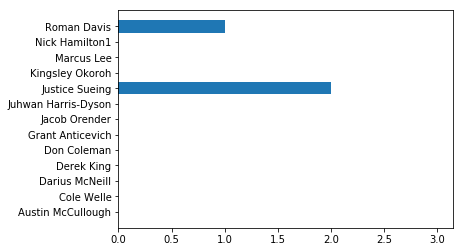

```
Furd Assists
```

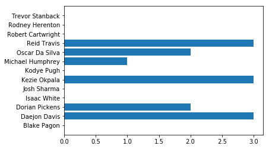

```python
calPlayers = bearsTable.column("Starters")[:-1]
calAssists = bearsTable.column("AST")[:-1]
plt.barh(calPlayers, calAssists)
plt.xlim(0, 3.15)
print("Cal Assists")
plt.show()

furdPlayers = furdTable.column("Starters")[:-1]
furdAssists = furdTable.column("AST")[:-1]
plt.barh(furdPlayers, furdAssists)
print("Furd Assists")
plt.show()
```

Some other failures in the game are best described very simply. Marcus Lee, and Don Coleman did far less than the team is used to expecting from them. Lee, who used to play with Karl-Anthony Towns, ended his college career with 2 points in this loss. Coleman has put up points in the 30s before, and finished the game with 1.

Kingsley Okoroh had a non-negligible "triple single" with 6 points, 6 rebounds and a very nice 5 blocks, but since my freshman year I've always wished he could be better at scoring in the paint, given his size.

Ultimately, I think these our biggest points of pain were the disappearance of McNeill's scoring and the team's lack of effective ball movement in the face of Stanfurd's defense. Although the team performed better in the second half, McNeill was completely underutilized after carrying our team in the first, and I think he would have helped our chance of winning with a few more points. Having 3 assists as the end of an game isn't great.

We got demolished by our rivals in the first round of this tourney, but at the end of the day, I don't blame the bears for this loss in a rebuilding year, and I'll be looking forward to a better team next season.